# Co-clustering: exploration statistique de corpus de tweets

Réalisé par:

- Naima AHMIM
- Siham TAHI

Groupe: AMSD

## Partie 1: Chargement et exploration de données

```r
library(Factoshiny)
```

```r
data=read.csv(file.choose(), header = TRUE, encoding="UTF-8")
```

```r
summary(data)
```

```
       id             user_name         user_location      user_description   user_created       user_followers      user_friends
 Min.   :1.338e+18   Length:11020       Length:11020       Length:11020       Length:11020       Min.   :       0   Min.   :     0
 1st Qu.:1.348e+18   Class :character   Class :character   Class :character   Class :character   1st Qu.:     111   1st Qu.:   164
 Median :1.360e+18   Mode  :character   Mode  :character   Mode  :character   Mode  :character   Median :     479   Median :   460
 Mean   :1.373e+18                                                                               Mean   :   35188   Mean   :  1170
 3rd Qu.:1.395e+18                                                                               3rd Qu.:    2171   3rd Qu.:  1221
 Max.   :1.463e+18                                                                               Max.   :13714928   Max.   :103226
 user_favourites   user_verified          date               text             hashtags            source             retweets        favorites
 Min.   :      0   Length:11020       Length:11020       Length:11020       Length:11020       Length:11020       Min.   :  0.00   Min.   :   0.000
 1st Qu.:    436   Class :character   Class :character   Class :character   Class :character   Class :character   1st Qu.:  0.00   1st Qu.:   0.000
 Median :   2324   Mode  :character   Mode  :character   Mode  :character   Mode  :character   Mode  :character   Median :  0.00   Median :   1.000
 Mean   :  15333                                                                                                  Mean   :  1.36   Mean   :   7.511
 3rd Qu.:  11141                                                                                                  3rd Qu.:  1.00   3rd Qu.:   4.000
 Max.   :1213794                                                                                                  Max.   :678.00   Max.   :2315.000
  is_retweet
 Length:11020
 Class :character
 Mode  :character
```

```r
#data.frame avec les messages uniques
#les premières occurrences sont récupérées
dfUnique <- data[!duplicated(data$text),]
```

```r
print(nrow(dfUnique))
```

```
[1] 11013
```

```r
messages <- dfUnique$text
print(length(messages))
```

```
[1] 11013
```

```r
#retrait du saut de ligne \n
msgClean <- iconv(messages, from="UTF-8", to="ASCII", sub="")
msgClean <- gsub("\n"," ",msgClean)
#retrait des URL
msgClean <- gsub('http\\S+\\s*',"",msgClean)
#retrait des espaces en trop
msgClean <- gsub("\\s+"," ",msgClean)
#retrait des "\"
msgClean <- gsub("[\\]","",msgClean)
#retrait des espaces en fin de texte
msgClean <- gsub("\\s*$","",msgClean)
#harmonisation de la casse - tout mettre en minuscule
msgClean <- tolower(msgClean)
#retrait des accents
msgClean <- gsub("[éèê]","e",msgClean)
msgClean <- gsub("[àâ]","a",msgClean)
msgClean <- gsub("[ùû]","u",msgClean)
```

```r
#retrait de l'indicateur de retweet
msgClean <- gsub("rt ","",msgClean)
#vérification - affichage du document 8
print(msgClean[8])
```

```
[1] "there have not been many bright days in 2020 but here are some of the best 1. #bidenharris winning #election2020"
```

```r
#enlever les doublons
msgClean <- msgClean[!duplicated(msgClean)]
#nombre de messages
print(length(msgClean))
```

```
[1] 10594
```

```r
#retrait des hashtags
msgCleanBis <- gsub("#[[:alnum:]_]*( |:|$)","",msgClean)
#retrait des pseudos
msgCleanBis <- gsub("@[[:alnum:]_]*( |:|$)","",msgCleanBis)
```

```r
library(tm)
## Loading required package: NLP
#transformation de la liste des tweets en un format interne
corpus <- Corpus(VectorSource(msgCleanBis))
print(corpus)
```

```
<<SimpleCorpus>>
Metadata:  corpus specific: 1, document level (indexed): 0
Content:  documents: 10594
```

```r
#retrait des ponctuations
corpus <- tm_map(corpus,removePunctuation)
#retrait des nombres
corpus <- tm_map(corpus,removeNumbers)
#retrait des stopwords (mots outils)

corpus <- tm_map(corpus,removeWords,stopwords("english"))
#retirer les espaces en trop (s'il en reste encore)
corpus <- tm_map(corpus,stripWhitespace)
#vérification avec le document n°8
print(corpus[[8]]$content)
```

```
[1] " many bright days best winning "
```

```r
#création de la bow à partir du corpus
bow <- DocumentTermMatrix(corpus,control=list(weighting = weightTfIdf))
bow
```

```
<<DocumentTermMatrix (documents: 10594, terms: 11085)>>
Non-/sparse entries: 75440/117359050
Sparsity           : 100%
Maximal term length: 36
Weighting          : term frequency - inverse document frequency (normalized) (tf-idf)
```

```r
bow<- removeSparseTerms(bow, sparse=0.99)
m <- as.matrix(bow)
print(dim(m))
```

```
[1] 10594    90
```

```r
print(findFreqTerms(bow,60))
```

```
 [1] "said"           "side"           "vaccination"    "world"          "year"           "last"           "vaccine"        "need"
 [9] "covid"          "days"           "many"           "getting"        "says"           "will"           "first"          "people"
[17] "also"           "health"         "new"            "safety"         "receive"        "hours"          "vaccinated"     "amp"
[25] "cases"          "coronavirus"    "get"            "now"            "approval"       "day"            "emergency"      "fda"
[33] "mrna"           "use"            "dont"           "week"           "done"           "well"           "news"           "finally"
[41] "effects"        "one"            "pfizerbiontech" "like"           "dose"           "approved"       "two"            "vaccines"
[49] "received"       "shot"           "ive"            "weeks"          "doses"          "feeling"        "great"          "thank"
[57] "morning"        "just"           "pfizer"         "take"           "today"          "science"        "good"           "happy"
[65] "feel"           "given"          "work"           "still"          "full"           "million"        "effective"      "data"
[73] "can"            "thanks"         "grateful"       "arm"            "sore"           "know"           "yesterday"      "time"
[81] "government"     "got"            "receiving"      "jab"            "biontech"       "number"         "second"         "study"
[89] "booster"        "fully"
```

```r
#ne conserver que les termes apparaissant plus de 2 fois dans la matrice
docTermsClean <- m[,colSums(m) > 2]
print(dim(docTermsClean))
```

```
[1] 10594    90
```

```r
res.pca <- PCA(docTermsClean, graph= FALSE)
```

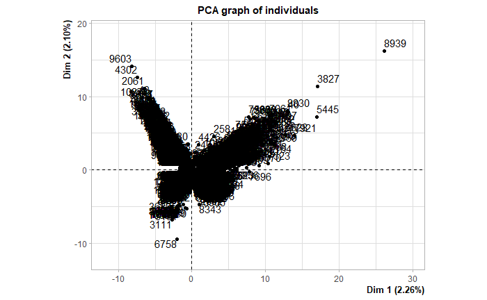

```r
plot(res.pca)
```

Nous remarquons que le taux d’information expliqué par les axes de la PCA est vraiment petit de plus nous ne voyons pas bien les classes.

```r
library('factoextra')
library('Rtsne')
library(NbClust)
```

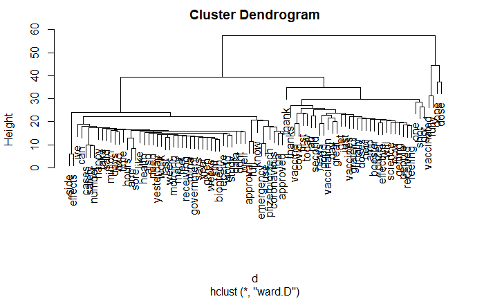

```r
d <- dist(t(bow), method = "euclidian") # Find Ecludian distance between terms
fit <- hclust(d, method = "ward.D")
plot(fit)
```

A partir de cette méthode nous pouvons prendre un k=3 ou k=6

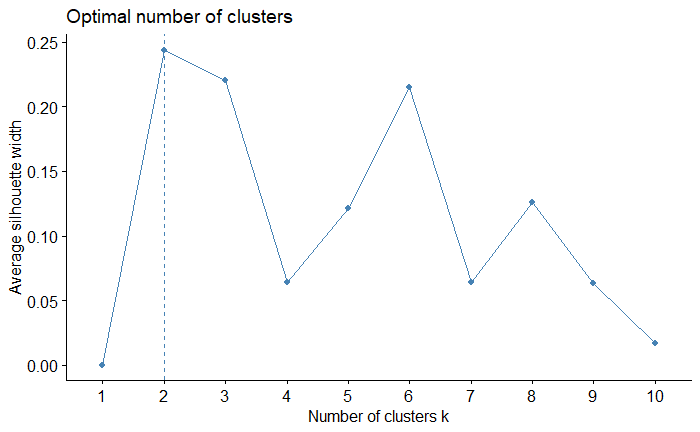

```r
set.seed(123)
fviz_nbclust(docTermsClean, kmeans, method = "silhouette")
```

La méthode de la solhouette nous a donné un k=2 comme nombre de classes

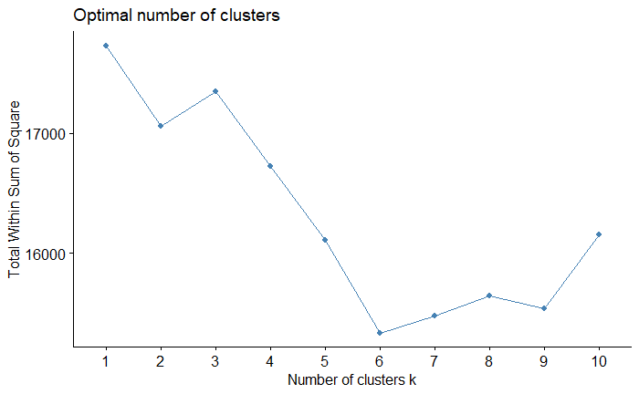

```r
set.seed(123)
fviz_nbclust(docTermsClean, kmeans, method = "wss")
```

La méthode du coude n’a pas donné de bons résultats, nous pouvons prendre un k=6 et voir les clusters formés.

```r
k2 <- kmeans(docTermsClean, centers = 2, nstart = 25)
k3 <- kmeans(docTermsClean, centers = 3, nstart = 25)
k6 <- kmeans(docTermsClean, centers = 6, nstart = 25)
```

```r
p1 <- fviz_cluster(k2, geom = "point", data = docTermsClean) + ggtitle("k = 2")
p2 <- fviz_cluster(k3, geom = "point",  data = docTermsClean) + ggtitle("k = 3")
p3 <- fviz_cluster(k6, geom = "point",  data = docTermsClean) + ggtitle("k = 6")
```

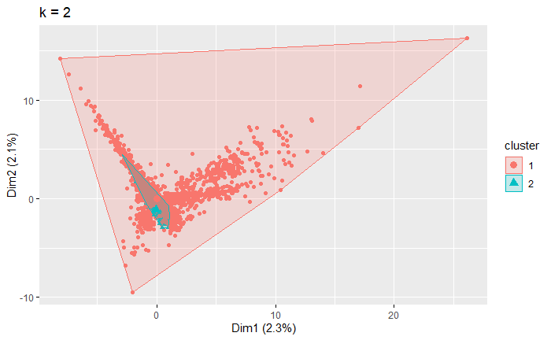

```r
p1
```

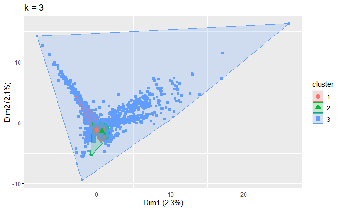

```r
p2
```

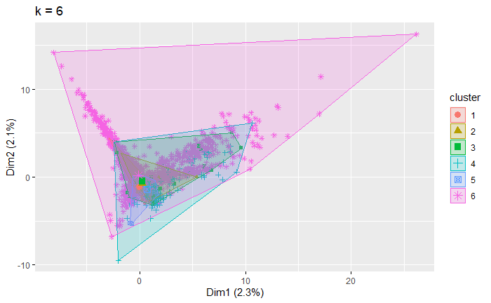

```r
p3
```

```r
tsne=Rtsne(docTermsClean,dim=2,perplexity=50,check_duplicates = FALSE)
```

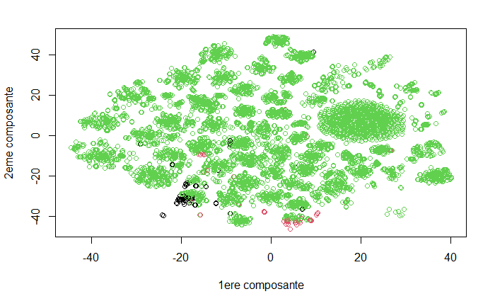

```r
plot(tsne$Y,col=k3$cluster, xlab="1ere composante", ylab="2eme composante")
```

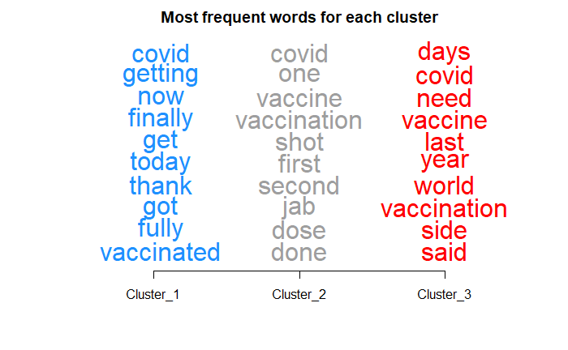

```r
library(deepMOU)
words_freq_plot(docTermsClean, k3$cluster,n_words = 10)
```

Nous remarquons que le 1er cluster contient des tweets positifs par rapport à la vaccination (thank, finally…), le 2eme contient des tweets sur les doses des vaccins (one, dose, done..) le dernier cluster contient des tweets neutres sur la covid et la vaccination.

# Co-Clustering

Dans cette partie, nous appliquons le co-clustering en utilisant la fontion cocluster du package blockcluster. Nous l’exécutons avec un nombre de ligne= 3 et un nombre de colonnes=3.

```r
library(blockcluster)
library(blockmodels)
```

```r
out<-cocluster(docTermsClean,datatype="contingency",nbcocluster= c(3,3))
```

```r
summary(out)
```

```
Model Family : Poisson Latent block model
Model Name : pik_rhol_unknown
Co-Clustering Type : Unsupervised
ICL value:  -85661

Model Parameters..

Class Gamma:
             [,1]       [,2]        [,3]
[1,] 1.208694e-02 0.04235829 0.023891143
[2,] 2.214458e-06 0.38819806 0.000279468
[3,] 3.059077e-04 0.12711376 0.077012434

Row proportions:  0.9317512 0.02012001 0.04812878
Column proportions:  0.6555556 0.08888889 0.2555556
Pseudo-likelihood:  -85585.28
```

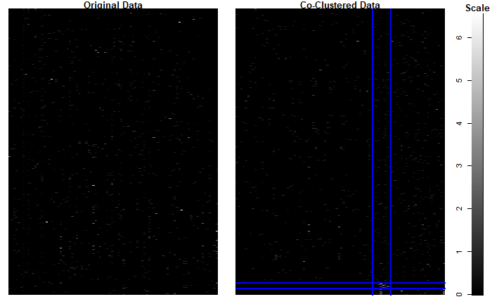

```r
plot(out)
```

Nous remarquons que la 1ere classe à une grande taille par rapport aux autres.